# InteroMap — Study 2 Report

Pre-registered hypotheses: linear mixed models and Study-1-informed Bayesian models

# Load data and prepare variables

```r
df <- read_csv(file.path(base_dir, "data", "processed", "interomap_study2_data.csv"),
               show_col_types = FALSE)

# Private demographics (one row per PID), used only for the Demographics table.
demo_path <- file.path(base_dir, "data", "processed", "interomap_study2_demographics.csv")
have_demographics <- file.exists(demo_path)

if (have_demographics) {
  df <- df |>
    left_join(read_csv(demo_path, show_col_types = FALSE), by = "PID")
} else {
  df <- df |>
    mutate(Age = NA_real_,
           Gender = NA_character_,
           `Cultural background` = NA_character_,
           `Racial lineage` = NA_character_)
}

# Study 1 fits provide the informed priors (produced by interomap_fit_models.R).
study1_fits <- readRDS(file.path(base_dir, "code", "study1_fits.rds"))

gender_levels <- c("Non-binary", "Woman", "Man", "Self-described/Other",
                   "Don't know", "No answer")

df <- df |>
  mutate(
    # Ensure Gender has every level in the scheme (code 3 is otherwise NA).
    Gender = factor(replace_na(as.character(Gender), "Self-described/Other"),
                    levels = gender_levels),
    # Valence centred at 0 for -5 to +5 descriptives (z-score is shift-invariant).
    avg_valence_centered = avg_valence_combined - 6,
    # The four pre-registered outcomes (z-scored within study).
    avg_valence_z       = as.numeric(scale(avg_valence_combined)),
    centroid_y_front_z  = as.numeric(scale(centroid_y_front)),
    sd_x_front_z        = as.numeric(scale(sd_x_front)),
    entropy_15_front_z  = as.numeric(scale(entropy_15_front)),
    timepoint = factor(timepoint, levels = c("pre", "post")),
    group     = factor(group, levels = c("non_gambler", "gambler")),
    PID       = factor(PID)
  )

# Raw columns for descriptives and distributions.
pre_reg_raw <- c(
  "Valence"      = "avg_valence_centered",
  "Centroid y"   = "centroid_y_front",
  "SD x"         = "sd_x_front",
  "Entropy (15)" = "entropy_15_front"
)

# Z-scored outcome columns used in the models.
study2_specs <- c(
  "Valence"      = "avg_valence_z",
  "Centroid y"   = "centroid_y_front_z",
  "SD x"         = "sd_x_front_z",
  "Entropy (15)" = "entropy_15_front_z"
)

# ---- Frequentist LME helpers ----

fit_lme <- function(dv, data) {
  lmer(as.formula(paste(dv, "~ timepoint * group + (1 | PID)")),
       data = data, REML = TRUE)
}

# Satterthwaite-df fixed effects, formatted for an APA table (Wald 95% CI).
lme_effects_table <- function(fit) {
  s <- summary(fit)$coefficients
  labels <- c("Intercept", "Timepoint (post)", "Group (gambler)",
              "Timepoint x Group")
  data.frame(
    Parameter = labels,
    b         = round(s[, "Estimate"],   2),
    SE        = round(s[, "Std. Error"], 2),
    df        = round(s[, "df"],         1),
    t         = round(s[, "t value"],    2),
    p         = fmt_p(s[, "Pr(>|t|)"]),
    `95% CI`  = sprintf("[%.2f, %.2f]",
                        s[, "Estimate"] - 1.96 * s[, "Std. Error"],
                        s[, "Estimate"] + 1.96 * s[, "Std. Error"]),
    check.names = FALSE
  )
}

# ---- Bayesian helpers ----

fit_model <- function(dv, data, prior) {
  brm(
    formula = as.formula(paste(dv, "~ timepoint * group + (1 | PID)")),
    data    = data,
    prior   = prior,
    family  = gaussian(),
    iter    = 4000, warmup = 2000, chains = 4, cores = 4,
    seed    = SEED,
    backend = "cmdstanr",
    control = list(adapt_delta = 0.9),
    save_pars    = save_pars(all = TRUE),
    sample_prior = TRUE
  )
}

# Study 2 priors = normal(Study 1 posterior mean, Study 1 posterior SE),
# following Verhagen & Wagenmakers (2014).
build_informed_prior <- function(fit) {
  fx <- posterior_summary(
    fit,
    variable = c("b_Intercept", "b_timepointpost", "b_groupgambler",
                 "b_timepointpost:groupgambler")
  )
  sd_pid <- posterior_summary(fit, variable = "sd_PID__Intercept")

  c(
    set_prior(sprintf("normal(%s, %s)",
                      fx["b_Intercept", "Estimate"],
                      fx["b_Intercept", "Est.Error"]),
              class = "Intercept"),
    set_prior(sprintf("normal(%s, %s)",
                      fx["b_timepointpost", "Estimate"],
                      fx["b_timepointpost", "Est.Error"]),
              class = "b", coef = "timepointpost"),
    set_prior(sprintf("normal(%s, %s)",
                      fx["b_groupgambler", "Estimate"],
                      fx["b_groupgambler", "Est.Error"]),
              class = "b", coef = "groupgambler"),
    set_prior(sprintf("normal(%s, %s)",
                      fx["b_timepointpost:groupgambler", "Estimate"],
                      fx["b_timepointpost:groupgambler", "Est.Error"]),
              class = "b", coef = "timepointpost:groupgambler"),
    set_prior(sprintf("normal(%s, %s)",
                      sd_pid["sd_PID__Intercept", "Estimate"],
                      sd_pid["sd_PID__Intercept", "Est.Error"]),
              class = "sd")
  )
}

# Posterior summary of the four fixed effects,
bayes_effects_table <- function(fit, include_bf = FALSE) {
  params <- c("Intercept", "timepointpost", "groupgambler",
              "timepointpost:groupgambler")
  labels <- c("Intercept", "Timepoint (post)", "Group (gambler)",
              "Timepoint x Group")

  s <- posterior_summary(fit, variable = paste0("b_", params))
  out <- data.frame(
    Parameter = labels,
    b         = round(s[, "Estimate"],  2),
    SE        = round(s[, "Est.Error"], 2),
    `95% CrI` = sprintf("[%.2f, %.2f]", s[, "Q2.5"], s[, "Q97.5"]),
    check.names = FALSE
  )

  if (include_bf) {
    slope_params <- params[-1]
    h <- hypothesis(fit, paste0(slope_params, " = 0"))$hypothesis
    out$BF01 <- c("\u2014", sprintf("%.3g", h$Evid.Ratio))
    out$BF10 <- c("\u2014", sprintf("%.3g", 1 / h$Evid.Ratio))
  }
  out
}

means_plot <- function(data, dv, label) {
  data |>
    group_by(timepoint, group) |>
    summarise(mean = mean(.data[[dv]], na.rm = TRUE),
              se   = sd(.data[[dv]], na.rm = TRUE) / sqrt(n()),
              .groups = "drop") |>
    ggplot(aes(x = timepoint, y = mean, colour = group, group = group)) +
    geom_line() +
    geom_point() +
    geom_errorbar(aes(ymin = mean - se, ymax = mean + se), width = 0.1) +
    labs(x = "Timepoint", y = paste0(label, " (z)"), colour = "Group") +
    theme_minimal()
}

distribution_plot <- function(data, specs) {
  data |>
    select(all_of(unname(specs))) |>
    pivot_longer(everything(), names_to = "metric", values_to = "value") |>
    filter(!is.na(value)) |>
    mutate(metric = factor(metric, levels = unname(specs), labels = names(specs))) |>
    ggplot(aes(x = value)) +
    geom_histogram(bins = 30, fill = "#4A90A4", colour = "white", alpha = 0.85) +
    facet_wrap(~ metric, scales = "free") +
    labs(x = "Raw value", y = "Count") +
    theme_minimal()
}
```

# Demographics

Age, gender, cultural background and racial lineage, split by gambling group. Education and employment are not reported.

```r
if (have_demographics) {
  demo <- df |>
  filter(timepoint == "pre") |>
  mutate(group = factor(group, levels = c("non_gambler", "gambler"),
                        labels = c("Non-Gambler", "Gambler")))

groups <- c("Non-Gambler", "Gambler")

gender_labels   <- gender_levels
cultural_labels <- c("African", "European", "East Asian", "South Asian",
                     "South East Asian", "Hispanic or Latinx", "Indigenous",
                     "Middle Eastern", "Other", "Don't know",
                     "Prefer not to answer")
racial_labels   <- c("Asian", "Black", "European/White", "Hispanic", "Indigenous",
                     "Pacific Islander", "Other", "Don't know",
                     "Prefer not to answer")

# Percentages rounded (largest remainder) so they sum to exactly 100%.
pct_sum100 <- function(counts) {
  n <- sum(counts)
  tenths <- floor(1000 * counts / n)
  remainder <- as.integer(round(1000 - sum(tenths)))
  frac <- 1000 * counts / n - tenths
  idx <- order(frac, counts, decreasing = TRUE)[seq_len(remainder)]
  tenths[idx] <- tenths[idx] + 1
  tenths / 10
}

# Gender is single-select: count each level (zero counts shown).
count_pct <- function(x, labels) {
  vals <- trimws(unlist(strsplit(as.character(x), ",")))
  vals <- vals[nzchar(vals)]
  cnt  <- as.numeric(table(factor(vals, levels = labels)))
  setNames(sprintf("%d (%.1f%%)", cnt, pct_sum100(cnt)), labels)
}

# Cultural background and racial lineage are multi-select.
combo_counts <- function(x, labels) {
  parsed <- lapply(replace_na(as.character(x), ""), function(z) {
    s <- trimws(strsplit(z, ",", fixed = TRUE)[[1]])
    s <- s[nzchar(s) & s %in% labels]
    if (length(s)) s[order(match(s, labels))] else character(0)
  })
  keys <- vapply(parsed, paste, character(1), collapse = ", ")
  keys <- keys[lengths(parsed) > 0]
  cnt  <- table(keys)
  setNames(sprintf("%d (%.1f%%)", cnt, pct_sum100(cnt)), names(cnt))
}

combo_order <- function(keys, labels) {
  parsed   <- strsplit(keys, ", ", fixed = TRUE)
  ranks    <- lapply(parsed, function(s) match(s, labels))
  size     <- lengths(ranks)
  rank_str <- vapply(ranks, function(r) paste(sprintf("%02d", r), collapse = ""), character(1))
  keys[order(size, rank_str)]
}

rows <- list()
rows[["n"]] <- sapply(groups, function(g) sum(demo$group == g, na.rm = TRUE))
rows[["Age, mean (SD)"]] <- sapply(groups, function(g) {
  x <- demo$Age[demo$group == g]
  sprintf("%.1f (%.1f)", mean(x, na.rm = TRUE), sd(x, na.rm = TRUE))
})
for (lab in gender_labels) {
  rows[[paste0("Gender \u2014 ", lab)]] <-
    sapply(groups, function(g) count_pct(demo$Gender[demo$group == g], gender_labels)[[lab]])
}

add_multi_rows <- function(rows, var, labels) {
  by_group <- lapply(groups, function(g) combo_counts(demo[[var]][demo$group == g], labels))
  keys <- combo_order(unique(c(labels, unlist(lapply(by_group, names)))), labels)
  for (k in keys) {
    rows[[paste0(var, " \u2014 ", k)]] <-
      sapply(by_group, function(v) if (k %in% names(v)) v[[k]] else "0 (0.0%)")
  }
  rows
}
rows <- add_multi_rows(rows, "Cultural background", cultural_labels)
rows <- add_multi_rows(rows, "Racial lineage", racial_labels)

demo_tab <- data.frame(Characteristic = names(rows),
                       `Non-Gambler`  = sapply(rows, `[`, 1),
                       Gambler        = sapply(rows, `[`, 2),
                       check.names = FALSE, row.names = NULL)

  cat(apa_tab_caption("Demographics by Group (Study 2)"), "\n")
  apa_table(demo_tab, "study2_demographics", tab_dir)
} else {
  cat("Demographics are not included in the shared data file.\n")
}
```

```
## **Table 1**
##
## *Demographics by Group (Study 2)*
```

[output not shown]

# Descriptives: pre-registered metrics

Mean (SD) in raw units, by group and timepoint. Valence is the per-pixel average valence, on a -5 to +5 scale (0 = midpoint).

```r
desc <- df |>
  mutate(timepoint = factor(timepoint, levels = c("pre", "post"),
                            labels = c("Pre", "Post")),
         group     = factor(group, levels = c("non_gambler", "gambler"),
                            labels = c("Non-Gambler", "Gambler"))) |>
  pivot_longer(cols = all_of(unname(pre_reg_raw)),
               names_to = "metric", values_to = "value") |>
  mutate(metric = factor(metric, levels = unname(pre_reg_raw),
                         labels = names(pre_reg_raw))) |>
  group_by(metric, timepoint, group) |>
  summarise(txt = sprintf("%.2f (%.2f)",
                          mean(value, na.rm = TRUE), sd(value, na.rm = TRUE)),
            .groups = "drop") |>
  pivot_wider(names_from = group, values_from = txt) |>
  arrange(metric, timepoint) |>
  rename(Metric = metric, Timepoint = timepoint)

cat(apa_tab_caption("Pre-registered Outcomes by Group and Timepoint (Study 2)"), "\n")
```

```
## **Table 2**
##
## *Pre-registered Outcomes by Group and Timepoint (Study 2)*
```

```r
apa_table(desc, "study2_descriptives", tab_dir)
```

[output not shown]

# Distributions

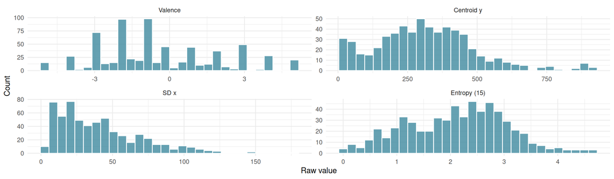

```r
pdist <- distribution_plot(df, pre_reg_raw)
apa_fig(pdist, "study2_dist", fig_dir, width = 12, height = 3.5)
pdist
```

# Linear mixed-effects models (frequentist)

Each of the four pre-registered outcomes is modelled with

$$\text{outcome}_z \sim \text{timepoint}
\times \text{group} + (1 \mid \text{PID})$$

using `lmerTest::lmer` with Satterthwaite degrees of freedom.

```r
study2_lme <- setNames(lapply(study2_specs, function(dv) fit_lme(dv, df)),
                       study2_specs)
```

### Valence

**Model:** `avg_valence_z ~ timepoint * group + (1 | PID)`

**Table 3**

*Linear Mixed Model Fixed Effects — Valence (Study 2)* [1] “

| Intercept | 0.17 | 0.07 | 634.1 | 2.34 | .020 | [0.03, 0.32] |
| --- | --- | --- | --- | --- | --- | --- |
| Timepoint (post) | -0.29 | 0.09 | 343.4 | -3.22 | .001 | [-0.46, -0.11] |
| Group (gambler) | -0.15 | 0.11 | 633.9 | -1.43 | .153 | [-0.36, 0.06] |

”

*Note.* b = unstandardised coefficient (outcome in SD units); Wald 95% CI; df = Satterthwaite degrees of freedom.

### Centroid y

**Model:** `centroid_y_front_z ~ timepoint * group + (1 | PID)`

**Table 4**

*Linear Mixed Model Fixed Effects — Centroid y (Study 2)* [1] “

| Intercept | 0.20 | 0.08 | 512.0 | 2.59 | .010 | [0.05, 0.35] |
| --- | --- | --- | --- | --- | --- | --- |
| Timepoint (post) | -0.37 | 0.08 | 289.4 | -4.69 | < .001 | [-0.52, -0.21] |
| Group (gambler) | -0.02 | 0.11 | 511.2 | -0.19 | .846 | [-0.24, 0.20] |

”

*Note.* b = unstandardised coefficient (outcome in SD units); Wald 95% CI; df = Satterthwaite degrees of freedom.

### SD x

**Model:** `sd_x_front_z ~ timepoint * group + (1 | PID)`

**Table 5**

*Linear Mixed Model Fixed Effects — SD x (Study 2)* [1] “

| Intercept | 0.15 | 0.08 | 517.2 | 1.94 | .052 | [-0.00, 0.31] |
| --- | --- | --- | --- | --- | --- | --- |
| Timepoint (post) | -0.19 | 0.08 | 303.1 | -2.36 | .019 | [-0.34, -0.03] |
| Group (gambler) | -0.17 | 0.11 | 516.4 | -1.51 | .131 | [-0.39, 0.05] |

”

*Note.* b = unstandardised coefficient (outcome in SD units); Wald 95% CI; df = Satterthwaite degrees of freedom.

### Entropy (15)

**Model:** `entropy_15_front_z ~ timepoint * group + (1 | PID)`

**Table 6**

*Linear Mixed Model Fixed Effects — Entropy (15) (Study 2)* [1] “

| Intercept | 0.18 | 0.08 | 459.0 | 2.34 | .020 | [0.03, 0.33] |
| --- | --- | --- | --- | --- | --- | --- |
| Timepoint (post) | -0.27 | 0.06 | 284.7 | -4.28 | < .001 | [-0.40, -0.15] |
| Group (gambler) | -0.19 | 0.11 | 458.2 | -1.70 | .090 | [-0.41, 0.03] |

”

*Note.* b = unstandardised coefficient (outcome in SD units); Wald 95% CI; df = Satterthwaite degrees of freedom.

# Bayesian models (Study-1-informed priors)

Each of the four pre-registered outcomes is modelled with

$$\text{outcome}_z \sim \text{timepoint}
\times \text{group} + (1 \mid \text{PID})$$

using priors informed by the corresponding Study 1 posterior: each fixed effect gets a `normal(Study 1 mean, Study 1 SE)` prior, and the random-intercept SD keeps a normal prior (truncated at zero by brms). Two-sided Bayes factors for the slopes are computed with the Savage–Dickey density ratio (`BF01` = evidence for the null, `BF10` = evidence against it).

```r
fits_path <- file.path(base_dir, "code", "study2_fits.rds")
if (!file.exists(fits_path)) {
  stop("study2_fits.rds not found; run interomap_fit_models.R first.")
}
study2_fits <- readRDS(fits_path)
```

### Valence

**Model:** `avg_valence_z ~ timepoint * group + (1 | PID)`

**Table 7**

*Bayesian Posterior Summary and Bayes Factors — Valence (Study 2)* [1] “

| Intercept | 0.16 | 0.06 | [0.04, 0.27] | — | — |
| --- | --- | --- | --- | --- | --- |
| Timepoint (post) | -0.26 | 0.06 | [-0.38, -0.14] | 0.000931 | 1.07e+03 |
| Group (gambler) | -0.14 | 0.08 | [-0.30, 0.02] | 0.512 | 1.95 |

”

*Note.* b = posterior mean; SE = posterior SD; 95% CrI = 95% credible interval; BF01 = evidence for the null; BF10 = evidence against the null.

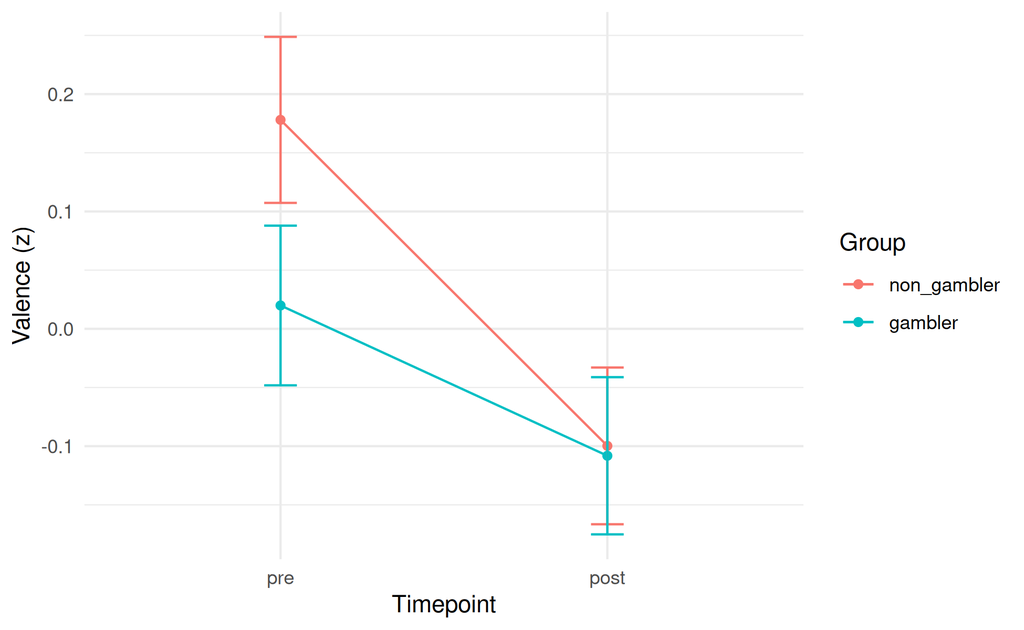

**Figure 1**

*Mean valence (z-scored) by timepoint and group — Study 2*

### Centroid y

**Model:** `centroid_y_front_z ~ timepoint * group + (1 | PID)`

**Table 8**

*Bayesian Posterior Summary and Bayes Factors — Centroid y (Study 2)* [1] “

| Intercept | 0.30 | 0.06 | [0.17, 0.42] | — | — |
| --- | --- | --- | --- | --- | --- |
| Timepoint (post) | -0.38 | 0.05 | [-0.49, -0.28] | 1.63e-113 | 6.12e+112 |
| Group (gambler) | -0.12 | 0.09 | [-0.28, 0.05] | 2.53 | 0.395 |

”

*Note.* b = posterior mean; SE = posterior SD; 95% CrI = 95% credible interval; BF01 = evidence for the null; BF10 = evidence against the null.

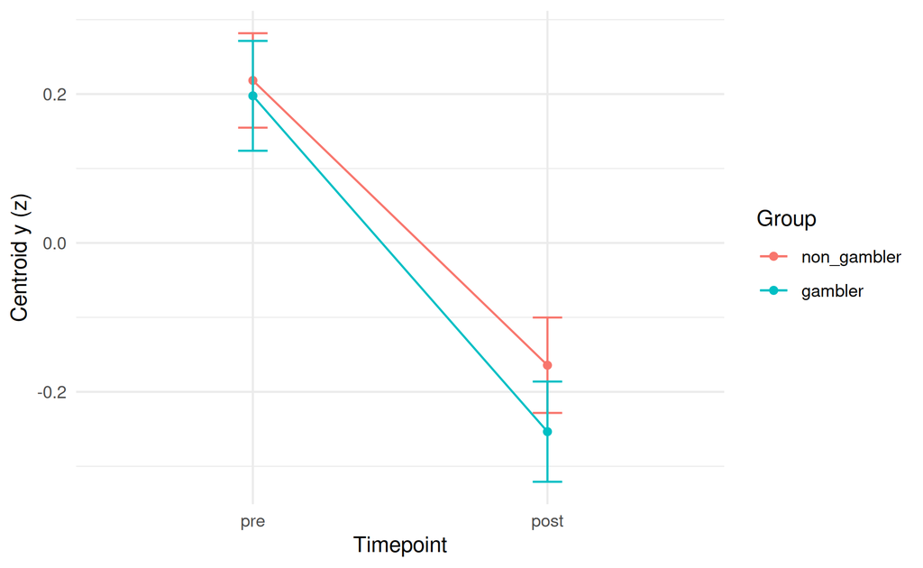

**Figure 2**

*Mean centroid y (z-scored) by timepoint and group — Study 2*

### SD x

**Model:** `sd_x_front_z ~ timepoint * group + (1 | PID)`

**Table 9**

*Bayesian Posterior Summary and Bayes Factors — SD x (Study 2)* [1] “

| Intercept | 0.16 | 0.06 | [0.03, 0.29] | — | — |
| --- | --- | --- | --- | --- | --- |
| Timepoint (post) | -0.19 | 0.06 | [-0.30, -0.08] | 0.0559 | 17.9 |
| Group (gambler) | -0.13 | 0.09 | [-0.30, 0.04] | 0.588 | 1.7 |

”

*Note.* b = posterior mean; SE = posterior SD; 95% CrI = 95% credible interval; BF01 = evidence for the null; BF10 = evidence against the null.

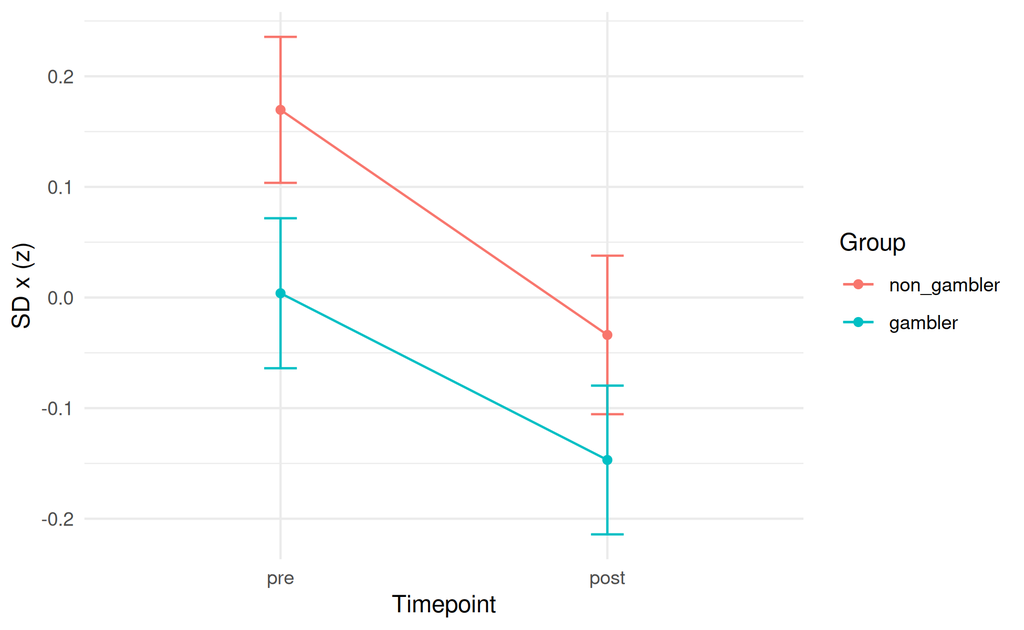

**Figure 3**

*Mean sd x (z-scored) by timepoint and group — Study 2*

### Entropy (15)

**Model:** `entropy_15_front_z ~ timepoint * group + (1 | PID)`

**Table 10**

*Bayesian Posterior Summary and Bayes Factors — Entropy (15) (Study 2)* [1] “

| Intercept | 0.09 | 0.07 | [-0.04, 0.22] | — | — |
| --- | --- | --- | --- | --- | --- |
| Timepoint (post) | -0.22 | 0.05 | [-0.31, -0.12] | 3.38e-08 | 2.96e+07 |
| Group (gambler) | -0.01 | 0.09 | [-0.18, 0.16] | 6.52 | 0.153 |

”

*Note.* b = posterior mean; SE = posterior SD; 95% CrI = 95% credible interval; BF01 = evidence for the null; BF10 = evidence against the null.

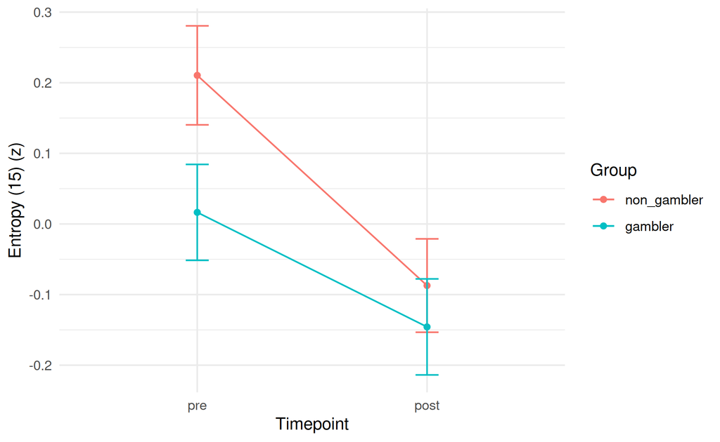

**Figure 4**

*Mean entropy (15) (z-scored) by timepoint and group — Study 2*

# Combined Bayes-factor summary

```r
bf_rows <- lapply(names(study2_specs), function(nm) {
  ft <- bayes_effects_table(study2_fits[[study2_specs[[nm]]]], include_bf = TRUE)
  ft$model <- nm
  ft[, c("model", "Parameter", "b", "SE", "95% CrI", "BF01", "BF10")]
})
bf_tab <- do.call(rbind, bf_rows)

cat(apa_tab_caption("Savage\u2013Dickey Bayes Factors Across Models (Study 2)"), "\n")
```

```
## **Table 11**
##
## *Savage–Dickey Bayes Factors Across Models (Study 2)*
```

```r
apa_table(bf_tab, "study2_bf_summary", tab_dir)
```

[output not shown]

# Prior vs posterior (distribution change across studies)

For each coefficient, the Study 1 posterior (which informed the Study 2 prior) is shown alongside the Study 2 posterior.

### Valence

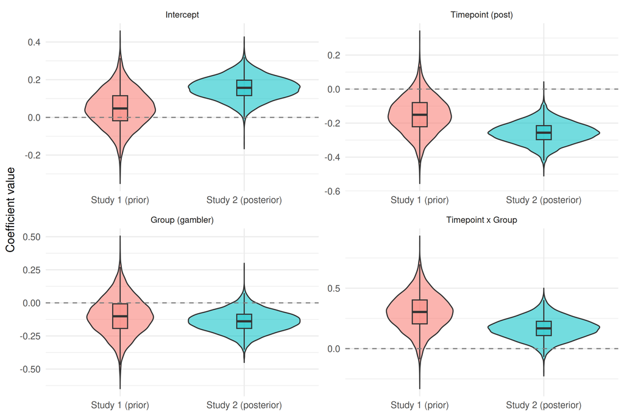

**Figure 5**

*Study 1 posterior vs Study 2 posterior for each coefficient — Valence*

### Centroid y

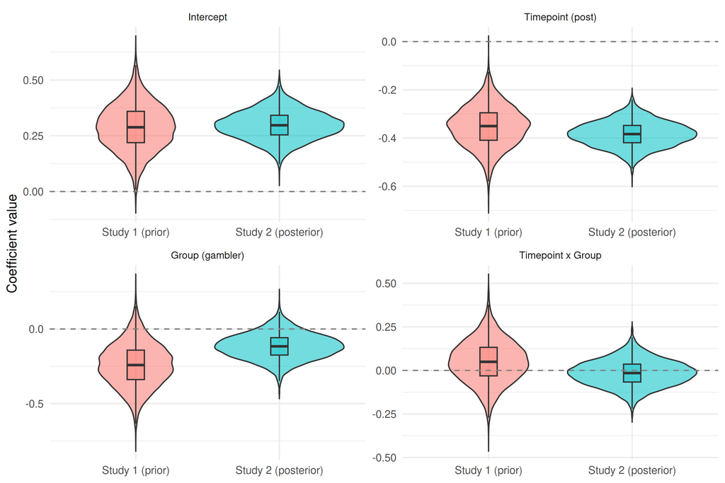

**Figure 6**

*Study 1 posterior vs Study 2 posterior for each coefficient — Centroid y*

### SD x

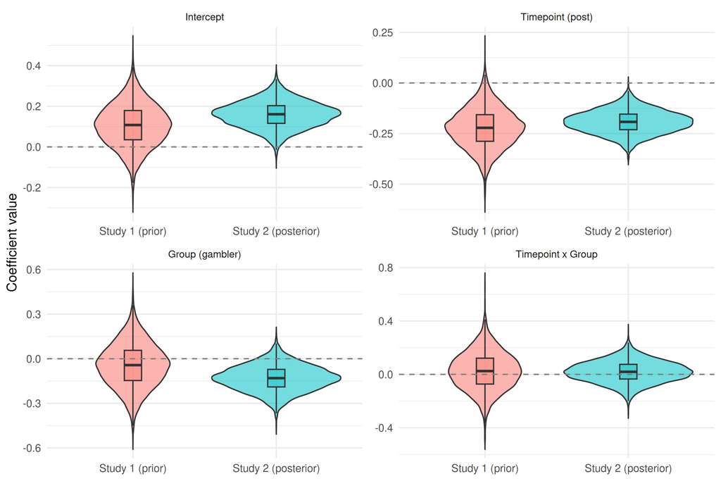

**Figure 7**

*Study 1 posterior vs Study 2 posterior for each coefficient — SD x*

### Entropy (15)

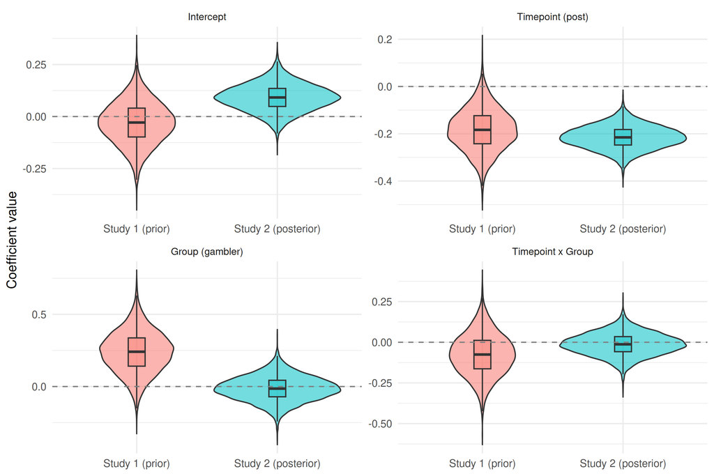

**Figure 8**

*Study 1 posterior vs Study 2 posterior for each coefficient — Entropy (15)*